# for_if 응용3_사용자함수 기본

### 사용자 함수

- def 로 시작한다.
- 기본형식: def 함수명(인수, ..):
- 사용자 함수=> 실행형/return형
- 함수호출: 함수명(인수 대입값, ..)
- 함수는 함수를 호출하는 코드 이전에 실행되어야 함

```python
# 실행형: 이름은 입력받아 출력해주는 함수
# 문자가 아닌 다른 형태의 자료 입력시 메세지 전달

def txt_print(name):
    if type(name) == str:
        print(f'{name}님, 안녕하세요.')
    else:
        print('문자만 출력 가능합니다.')


# 리턴형: 텍스트와 단어 입력후 텍스트에 포함된 단어의 개수를 계산 후 전달
def txt_count(txt, tsc):
    txtLen=len(tsc)    # txt에서 찾고자 하는 단어의 글자수
    cnt=0

    for i in range(len(txt)-(txtLen-1)):
        if txt[i:i+txtLen] == tsc:
            cnt=cnt+1

    return cnt
```

```python
txt_print(123)
```

```
문자만 출력 가능합니다.
```

```python
txt='''식물성 음식만 먹는 채식주의를 선호하는 사람들이 늘고 있다.
채식이 건강에 좋다고 생각해서 이를 실천하는 사람들도 있지만,
동물권을 존중해서 혹은 가축 사육으로 인한 환경 파괴 등의 문제로 채식을 하는 사람들도 있다.'''

단어=input('찾을 단어 입력: ')

txtcnt=txt_count(txt, 단어)
print(f'{단어} 개수: {txtcnt}개')
```

```
찾을 단어 입력: 사육으로 인한
사육으로 인한 개수: 1개
```

### 사용자 정의 함수

- 입력값을 가지고 어떤 일을 수행한 다음에 그 결과물을 내어놓는 것, 이것이 바로 함수가 하는 일이다.

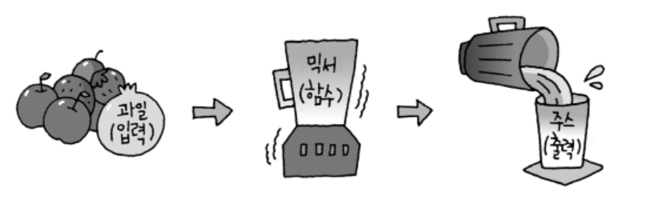

```python
txt='''식물성 음식만 먹는 채식주의를 선호하는 사람들이 늘고 있다.
채식이 건강에 좋다고 생각해서 이를 실천하는 사람들도 있지만,
동물권을 존중해서 혹은 가축 사육으로 인한 환경 파괴 등의 문제로 채식을 하는 사람들도 있다.'''

print(txt.split(" "))
```

```
['식물성', '음식만', '먹는', '채식주의를', '선호하는', '사람들이', '늘고', '있다.\n채식이', '건강에', '좋다고', '생각해서', '이를', '실천하는', '사람들도', '있지만,', '\n동물권을', '존중해서', '혹은', '가축', '사육으로', '인한', '환경', '파괴', '등의', '문제로', '채식을', '하는', '사람들도', '있다.']
```

### 입력받은 문자열을 스페이스바를 기준으로 문자 나누기

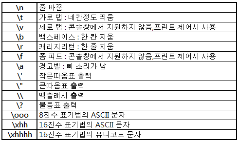

### 파이썬 비교연산

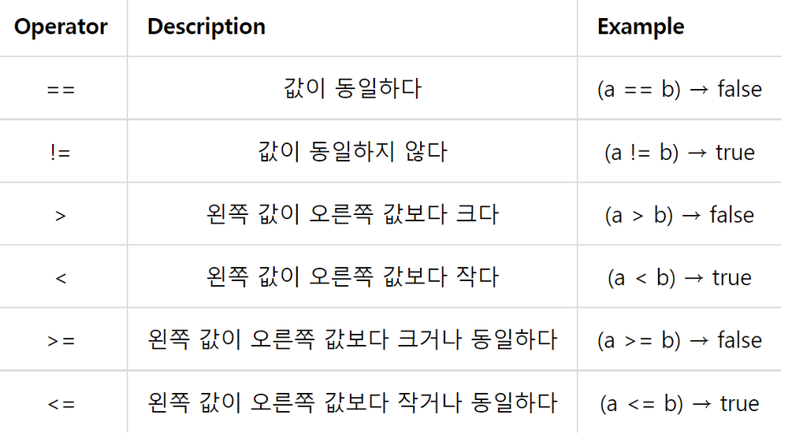

```python
# 입력받은 텍스트에 대하여 스페이스바 또는 사용자 입력 텍스트 기준으로 텍스트 나누기
# 설명을 위해 변수는 한글로 작성
def User_split(txt, spl=" "):
    나누는단어=spl
    리스트형_변수=[]
    단어_변수=""
    글자수=len(나누는단어)

    txt=txt.replace('\n', ',')

    for 순번 in range(len(txt)-(글자수-1)):
        if txt[순번:순번+글자수] != 나누는단어:
            단어_변수 = 단어_변수 + txt[순번]
        else:
            리스트형_변수.append(단어_변수)
            단어_변수=""

    if 단어_변수!="":
        리스트형_변수.append(단어_변수)

    return 리스트형_변수
```

```python
txt='''
식물성 음식만 먹는 채식주의를, 선호하는 사람들이 늘고 있다.
채식이 건강에, 좋다고 생각해서 이를 실천하는 사람들도 있지만,
동물권을 존중해서, 혹은 가축 사육으로, 인한 환경 파괴 등의, 문제로 채식을 하는 사람들도 있다.
'''

txt_lst=User_split(txt,",")
print(txt_lst)
```

```
['', '식물성 음식만 먹는 채식주의를', ' 선호하는 사람들이 늘고 있다.', '채식이 건강에', ' 좋다고 생각해서 이를 실천하는 사람들도 있지만', '', '동물권을 존중해서', ' 혹은 가축 사육으로', ' 인한 환경 파괴 등의', ' 문제로 채식을 하는 사람들도 있다.']
```

```python
def User_split(txt, spl= ' '):
    txt=txt.replace('\n', ' ')
    나누는_단어= spl
    리스트형_변수=[]
    단어_변수=""
    글자수 = len(나누는_단어)
    a=0
    for i in range(len(txt)-(글자수-1)):

            if txt[a:a+글자수] != 나누는_단어:
                단어_변수 += txt[a]
                a=i
            else:
                리스트형_변수.append(단어_변수)
                단어_변수=""
                a=i+글자수

    if 단어_변수 != " ":
        리스트형_변수.append(단어_변수)

    return 리스트형_변수
```

```python
lstData=[1,2,3,1,2,1,2,5,4,2,6,8,9,2,5,4,2,5,3,6,9,7]

num=int(input('숫자 입력: '))

print(num in lstData)   # a in 데이터  => a가 데이터 값들 안에 있다(True)/없다(False)를 찾아주는 연산자
print(num not in lstData)
```

```
숫자 입력: 5
True
False
```

```python
# 고유값 찾아 리스트형로 출력하기

lstData=[1,2,3,1,2,1,2,5,4,2,6,8,9,2,5,4,2,5,3,6,9,7]
lstPrn=[]   # 고유 데이터 저장 변수 생성

for num in lstData:
    if num in lstPrn:
        continue
    else:
        lstPrn.append(num)

print(lstPrn)
```

```
[1, 2, 3, 5, 4, 6, 8, 9, 7]
```

### 고유값 찾아 리스트형로 출력하기

- lstPrn에 데이터가 없으면 무조거 데이터 추가
- lstPrn에 입력된 데이터가 있다면 처음부터 현재 가져온 데이터가 있는지 확인
- - 데이터가 있는 경우 종료하고 다음 데이터로 이동
- - 끝까지 확인하였을때 없다면 lstPrn에 현재 가져온 데이터 추가 하고 다음 데이터로 이동

```python
lstData=[1,2,3,1,2,1,2,5,4,2,6,8,9,2,5,4,2,5,3,6,9,7]
lstPrn=[]   # 고유 데이터 저장 변수 생성

for num in lstData:
    if len(lstPrn)==0:
        lstPrn.append(num)
        continue     # 다음 데이터로 이동

    cnt=0
    for pr in lstPrn:
        if num == pr:
            cnt=cnt+1
            break   # 현재 진행중인 반복문을 벗어난다.

    if cnt == 0:
        lstPrn.append(num)

print(lstPrn)

del cnt
```

```
[1, 2, 3, 5, 4, 6, 8, 9, 7]
```

```python
lstData=[1,2,3,1,2,1,2,5,4,2,6,8,9,2,5,4,2,5,3,6,9,7]
lstPrn=[]   # 고유 데이터 저장 변수 생성

for num in lstData:
    if len(lstPrn)==0:
        lstPrn.append(num)
        continue     # 다음 데이터로 이동

    for i in range(len(lstPrn)):
        if num == lstPrn[i]:
             break   # 현재 진행중인 반복문을 벗어난다.

        if i == len(lstPrn)-1:
            lstPrn.append(num)

print(lstPrn)
```

```
[1, 2, 3, 5, 4, 6, 8, 9, 7]
```

### 번호 생성기

```python
import numpy as np
np.random.randint(1, 46)  # 1 ~ 45사이의 정수를 랜덤하게 1개 발생
```

```
11
```

```python
lstNum=[]
notNum=[7, 4, 11, 33, 44]

for i in range(100):
    num=np.random.randint(1, 46)
    if num not in lstNum:
        if num in notNum:
            continue
        else:
            lstNum.append(num)

        if len(lstNum) == 7:
            break

print(f'주번호:{lstNum[:-1]}, 보너스:{lstNum[-1]}')
```

```
주번호:[28, 35, 10, 16, 45, 9], 보너스:27
```